# Abortion in The United States.

Nhan Nguyen

2023-05-09

Introduction

- We will take a look at data on the number of legal abortions that take place in the United States each year – and other related measures – made by the Guttmacher Institute, which have tracked these patterns for several decades. The latest data is 2017(an update organizations was made in 2020).

Data Resource

- Data taking from the work of The Guttmacher Institute.

**Pregnancies, Births and Abortions in the United States: National and State Trends by Age Data Set (1988–2017)**

- Guttmacher data sets website: https://www.guttmacher.org/public-use-datasets
- The Institute compiles comprehensive statistics on the incidence of pregnancy, birth and abortion for people in all reproductive age-groups in the United States at the national level (1973–2017) and state level (1988–2017).
- Data set has been modified at 2021 so the information is the current newest one.

Data Resource (Continous)

**Abortion Surveillance — United States, 2019**

- Link: https://www.cdc.gov/mmwr/volumes/70/ss/ss7009a1.htm#T14_down
- Author: Katherine Kortsmit, PhD; Michele G. Mandel; Jennifer A. Reeves, MD; Elizabeth Clark, MD; H. Pamela Pagano, DrPH; Antoinette Nguyen, MD; Emily E. Petersen, MD; Maura K. Whiteman, PhD
- Release Date: November 26, 2021

**Texas and The U.S. population data set** - Link: https://www.tsl.texas.gov/ref/abouttx/census.html

- Sources: Forstall, Richard L. Population of States and Counties of the United States: 1790 to 1990. U.S. Bureau of the Census, Washington, DC, 1996.
- Release Date: NA, last modified January 8, 2020
- Another data set to support The U.S. population: https://www.macrotrends.net/states/texas/population
- Retrieved 2023-04-27.

Library import

```r
library(dplyr)
library(tidyverse)
library(stringr)
library(ggplot2)
```

So, what are the data sets we will working with? - Main data set to focus on is Guttmacher dataset.

- In this data set, we have all the data about pregnancy rate, birth rate, abortion rate, ratio, and number of abortions across the country.
- All of them was separated into some small group by age: Lower than 15, 15-17, 18-19, 15-19, lower than 20, 20-24, 25-29, 30-34, 35-39, and over 40. Rate scale is counting by 1/1000.
- All of the data that named as 15-19 are equal to the sum of 15-17 and 18-19 data.
- All of the data that named as lower than 20 are equal to the sum of lower than 15 and 15-19 data.(a little difference between them but not too much, under 1% difference when counting)
- Since some of the data have some gap between each year since some states don’t share it, I will pick some age groups that have the complete data thorough time to work on it.
- The group I choose to work on it is: age lower than 15, lower than 20, 20-24, 25-29, 30-34, 35-39, and over 40

```r
abortion_data_U.S <- read.csv(
"https://raw.githubusercontent.com/nhanizDee/R--for-data-science/main/NationalAndStatePregnancy_PublicUse.csv")
```

```r
population_data <- read.csv('State_Population.csv')

texas_population <- read.csv('Texas Population.csv')


# Clean and convert population column
population_data$Population <- as.numeric(gsub(",", "", population_data$Population))
texas_population$Population <- as.numeric(gsub(",", "", texas_population$Population))
```

How many abortions are there in the U.S. each year? - An exact answer is hard to come by.

- The Guttmacher Institute compiles data figures after contacting every known provider of abortions – clinics, hospitals and physicians’ offices – in the country.

Let’s first take a look at the number in the whole country by time:

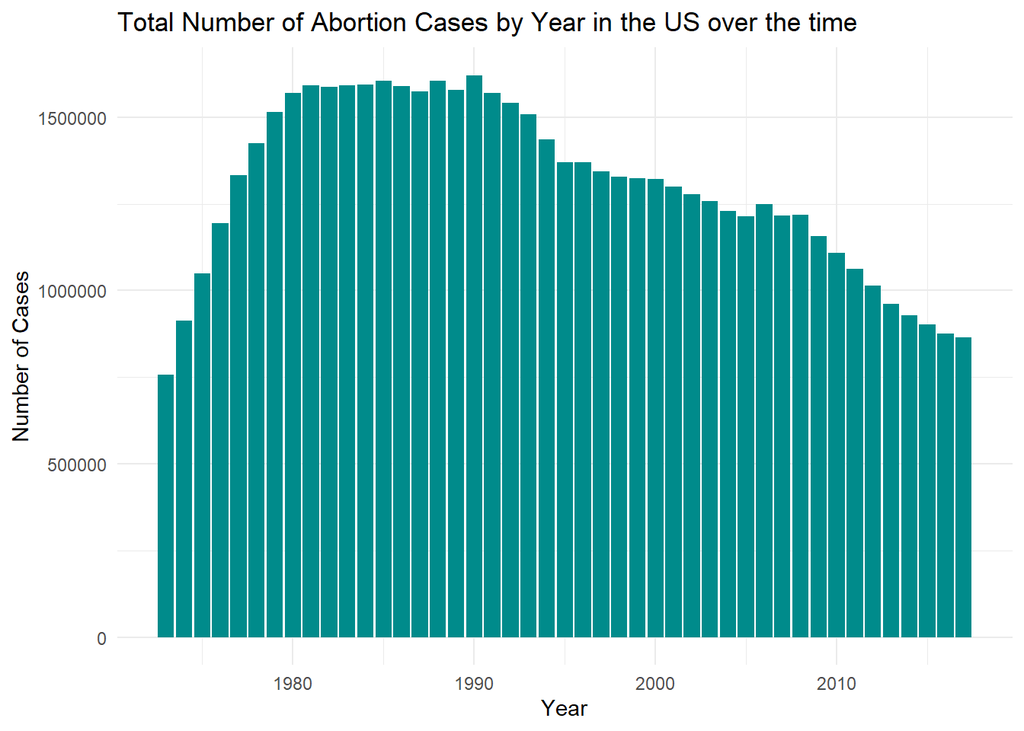

After that, let working on some specific states to see how it is going around us

Take a first look about population raking in the US.

```
##    Ranked     State.Name Population
## 1       1     California   39029342
## 2       2          Texas   30029572
## 3       3        Florida   22244823
## 4       4       New York   19677151
## 5       5   Pennsylvania   12972008
## 6       6       Illinois   12582032
## 7       7           Ohio   11756058
## 8       8        Georgia   10912876
## 9       9 North Carolina   10698973
## 10     10       Michigan   10034113
```

How about top 10 by rate

```
##    state rate_total
## 1     NJ       28.0
## 2     NY       26.3
## 3     MD       22.7
## 4     DC       21.1
## 5     FL       17.9
## 6     CT       17.8
## 7     NV       16.5
## 8     CA       16.3
## 9     RI       15.8
## 10    DE       15.5
```

Then let’s see top 10 of abortion case and rate in the US.

```
##    state case_total
## 1     CA     131380
## 2     NY     103060
## 3     FL      68640
## 4     TX      56340
## 5     NJ      47010
## 6     IL      37770
## 7     PA      33910
## 8     GA      32520
## 9     MD      26940
## 10    MI      26130
```

So the top ten state with the most abortion case in 2017 is:

| Rank | State Name |
| --- | --- |
| 1 | California |
| 2 | New York |
| 3 | Florida |
| 4 | Texas |
| 5 | New Jersey |
| 6 | Illinois |
| 7 | Pennsylvania |
| 8 | Georgia |
| 9 | Mary Land |
| 10 | Michigan |

We again see some familiar names here: California, Texas, Florida, New York, Pennsylvania, Illinois, Georgia, Michigan, and New Jersey.

A deeper look at abortion data in New Jersey:

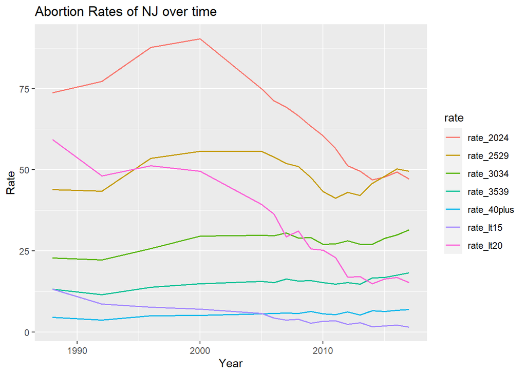

Or, using geom_area to have a better view

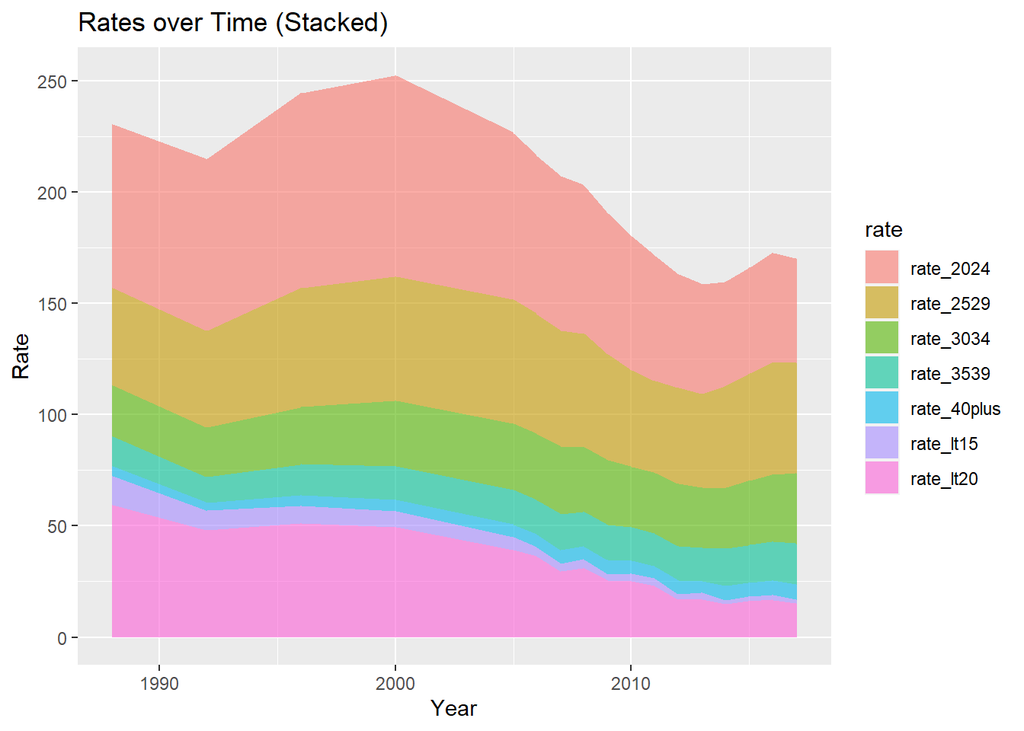

Base on the data form Guttmacher Institute:

- There was a increase in the abortion rate in New Jersey between 2014 and 2017.
- Case increase from 25.8 to 28.0 abortions per 1,000 women(of reproductive age).
- It represent 5.6% of all abortions in the United States.
- We are living in Texas, why don’t we take a look on the data of Texas!
- Here is the map of banned states:

[figure not shown]

Graph provided by KFF. For more information, you can take a look on this site:

https://www.kff.org/womens-health-policy/dashboard/abortion-in-the-u-s-dashboard/#state

- Before Roe v. Wade was overturned, at least 50,000 Texans received abortions in the state each year.
  - Texas already had one of the most restrictive abortion laws in the country.
- Here how look like as a graph

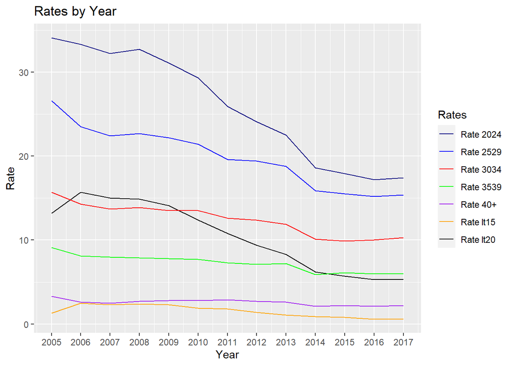

Abortion Rates by Age Group in Texas from 2005-2017

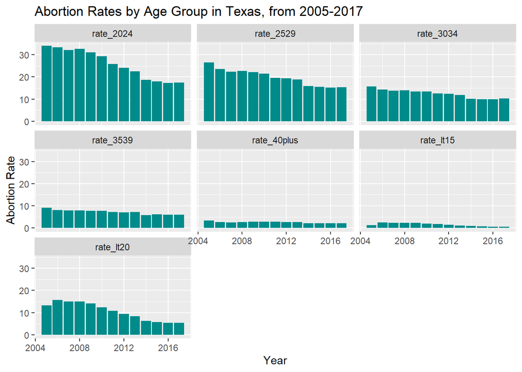

Abortion Cases by Age Group in Texas from 2005-2017

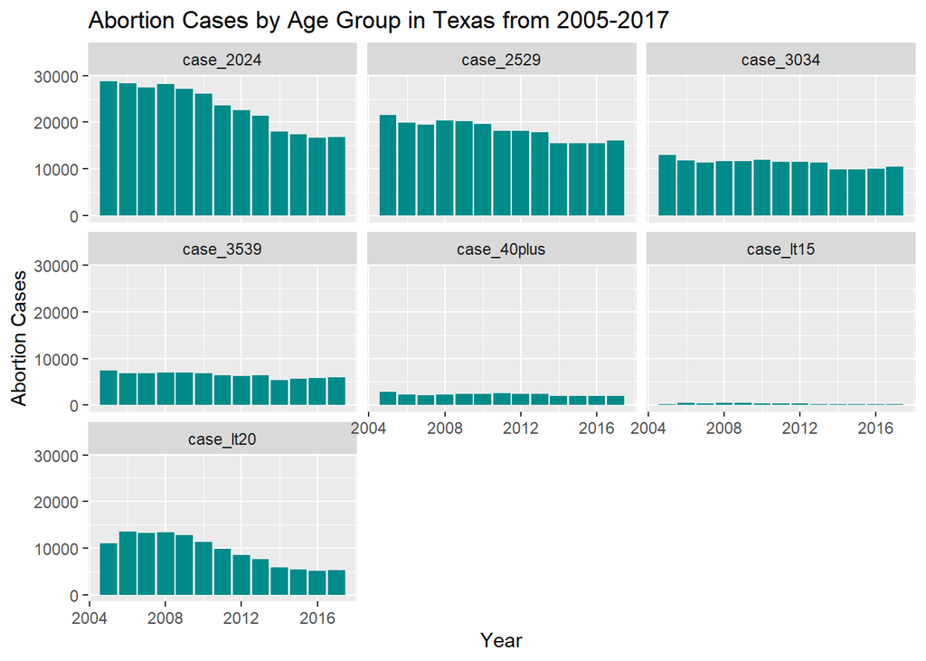

- One other the possible reason for it is: Texas does not require sex education and has the strictest abortion law in the nation.

How about the abortion rate of teen in Texas?

```
##    state Year rate_1517 rate_1819
## 1     TX 2006       7.9      26.5
## 2     TX 2008       7.6      24.9
## 3     TX 2010       6.1      20.9
## 4     TX 2012       4.3      16.3
## 5     TX 2014       2.7      11.2
## 6     TX 2016       2.4       9.8
## 7     US 2006      11.4      31.3
## 8     US 2008      10.6      29.1
## 9     US 2010       8.6      24.2
## 10    US 2012       6.4      19.7
## 11    US 2014       4.9      15.9
## 12    US 2016       4.0      13.8
```

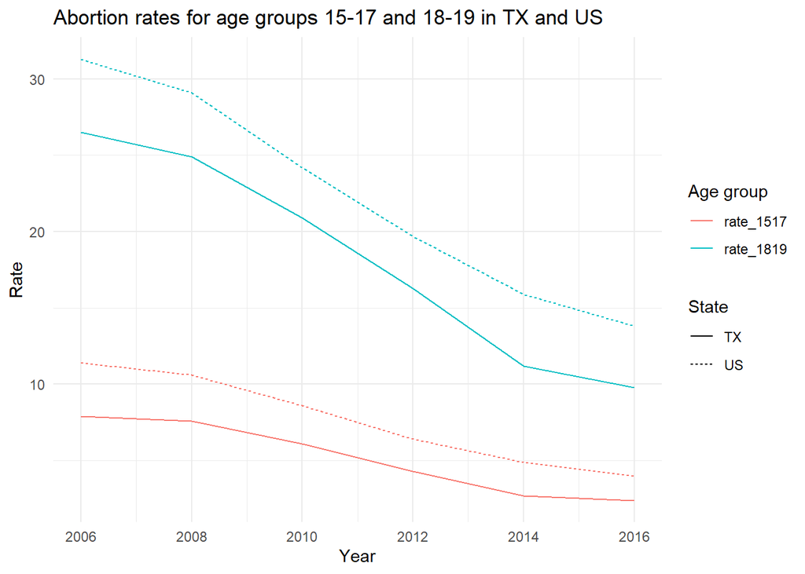

Some summary for the data: